# Testing Tourist Module

Bruno Caetano Vidigal

22 October 2015

In this document there are some statistics and summaries about the **Tourist Module**.

We need to compare the estimates for tourism consumption of **Tourist Module** for all the countries and commodities with **Food Data**. The **estimates** for **tourism consumption** with **103 distincts countries** and **419 distincts commodities** are below:

```
##    year country  item calNetCountry tourismElement flagObservationStatus
## 1: 2012     100 01211  4.581951e+01            100                     I
## 2: 2012     100 01212  3.116974e+02            100                     I
## 3: 2012     100 01213  2.035929e+01            100                     I
## 4: 2012     100 01214  3.827800e+01            100                     I
## 5: 2012     100 01215  9.939250e+00            100                     I
## 6: 2012     100 01216  7.792431e-03            100                     I
##    flagMethod
## 1:          e
## 2:          e
## 3:          e
## 4:          e
## 5:          e
## 6:          e
```

The **Food Data** with **103 distincts countries** and **419 distincts commodities** are below:

```
##    country  item year    totalCal
## 1:     100 01211 2012  5772.80979
## 2:     100 01212 2012 39270.81488
## 3:     100 01213 2012  2565.07145
## 4:     100 01214 2012  4822.65242
## 5:     100 01215 2012  1252.24811
## 6:     100 01216 2012     0.98177
```

**Merging** these datasets:

```
##    year country  item calNetCountry tourismElement flagObservationStatus
## 1: 2012     100 01211  4.581951e+01            100                     I
## 2: 2012     100 01212  3.116974e+02            100                     I
## 3: 2012     100 01213  2.035929e+01            100                     I
## 4: 2012     100 01214  3.827800e+01            100                     I
## 5: 2012     100 01215  9.939250e+00            100                     I
## 6: 2012     100 01216  7.792431e-03            100                     I
##    flagMethod    totalCal
## 1:          e  5772.80979
## 2:          e 39270.81488
## 3:          e  2565.07145
## 4:          e  4822.65242
## 5:          e  1252.24811
## 6:          e     0.98177
```

Now we can calculate **% tourism consumption** per country and per commoditie.

```
##    year country  item calNetCountry tourismElement flagObservationStatus
## 1: 2012     100 01211  4.581951e+01            100                     I
## 2: 2012     100 01212  3.116974e+02            100                     I
## 3: 2012     100 01213  2.035929e+01            100                     I
## 4: 2012     100 01214  3.827800e+01            100                     I
## 5: 2012     100 01215  9.939250e+00            100                     I
## 6: 2012     100 01216  7.792431e-03            100                     I
##    flagMethod    totalCal percentCalItemCountry
## 1:          e  5772.80979           0.007937125
## 2:          e 39270.81488           0.007937125
## 3:          e  2565.07145           0.007937125
## 4:          e  4822.65242           0.007937125
## 5:          e  1252.24811           0.007937125
## 6:          e     0.98177           0.007937125
```

When the estimates for tourism consumption is **negative** it means that more people **left this country**. If is **positive**, it means more people **went** to this country. So we can calculate which countries were more impacted with tourism consumption and which one had less tourism consumption in 2012.

Summary of estimates tourism consumption:

```
##       Min.    1st Qu.     Median       Mean    3rd Qu.       Max.
## -0.6718000 -0.0008387  0.0000000 -0.0039380  0.0022540  0.0633900
```

**Top 5 positive** estimated consumption per country for tourism. **Bahamas (44)** and **Seychelles (690)** are the two firsts countries with more % tourism consumption.

```
##    year country percentCalCountry rank
## 1: 2012      44        0.06339497    1
## 2: 2012     690        0.05044369    2
## 3: 2012      52        0.04656508    3
## 4: 2012      60        0.04331689    4
## 5: 2012     196        0.03953663    5
```

**Top 5 negative** estimated consumption per country for tourism. Note that **Albania (8)** has a strange number. It’s necessary to check it.

```
##    year country percentCalCountry rank
## 1: 2012     414       -0.02248057   99
## 2: 2012     756       -0.02675454  100
## 3: 2012     498       -0.02729250  101
## 4: 2012      96       -0.05843101  102
## 5: 2012       8       -0.67178611  103
```

The decis are:

```
##            0%           10%           20%           30%           40%
## -0.6717861103 -0.0054529332 -0.0017070904 -0.0002233375  0.0000000000
##           50%           60%           70%           80%           90%
##  0.0000000000  0.0000000000  0.0003557033  0.0037200530  0.0162760119
```

The histogram and BoxPlot are below:

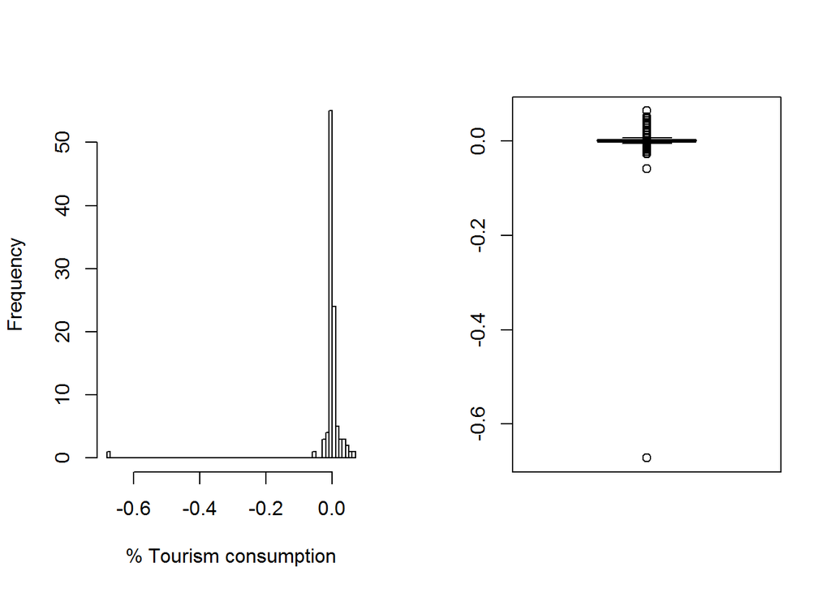

If we remove **Albania** this analyze, the new plots are:

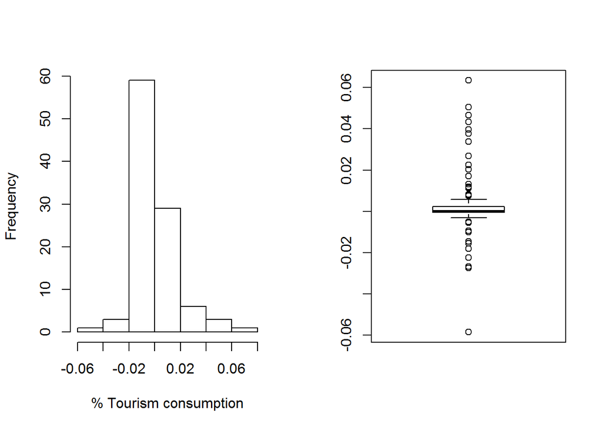

With this data, we have this % below about tourism consumption.

```
##    consumption  N percent
## 1:    positive 39    37.9
## 2:        zero 29    28.2
## 3:    negative 35    34.0
```